# Short R Tutorial: Validating Sequence Analysis Typologies Using Parametric Bootstrap

Matthias Studer

# Introduction

This document provides a very quick introduction to the `R` code needed to use parametric bootstraps for typology validation in sequence analysis. Readers interested in the methods and the exact interpretation of the results are referred to:

- Studer, M. (2021). Validating Sequence Analysis Typologies Using Parametric Bootstraps. *Sociological Methodology 51(2)*, 290–318. https://doi.org/10.1177/00811750211014232

You are kindly asked to cite the above reference if you use the methods presented in this document.

**Warning!!** To avoid lengthy computations (and overloading the CRAN server), we restricted the number of bootstraps to 50. We recommend using a higher value (i.e., 1000).

Let’s start by setting the seed for reproducible results.

```r
set.seed(1)
```

Time for this code chunk to run: 0.01 seconds

# Creating the State Sequence Object

For this example, we use the `mvad` dataset. Let’s start with the creation of the state sequence object.

```r
## Loading the TraMineR library
library(TraMineR)
## Loading the data
data(mvad)

## State properties
mvad.alphabet <- c("employment", "FE", "HE", "joblessness", "school", "training")
mvad.lab <- c("employment", "further education", "higher education", "joblessness", "school", "training")
mvad.shortlab <- c("EM","FE","HE","JL","SC","TR")

## Creating the state sequence object
mvad.seq <- seqdef(mvad, 17:86, alphabet = mvad.alphabet, states = mvad.shortlab, labels = mvad.lab, xtstep = 6)
```

Time for this code chunk to run: 0.18 seconds

# Creating the typology

We will now create a typology using cluster analysis. Readers interested in more detail are referred to the `WeightedCluster` library manual (also available as a vignette), which goes into the details of the creation and computation of cluster quality measures.

We start by computing dissimilarities with the `seqdist` function using the Hamming distance. We then use Ward clustering to create a typology of the trajectories. For this step, we recommend the use of the `fastcluster` library, which considerably speed up the computations.

```r
## Using fastcluster for hierarchical clustering
library(fastcluster)
## Distance computation
diss <- seqdist(mvad.seq, method="HAM")
## Hierarchical clustering
hc <- hclust(as.dist(diss), method="ward.D")
```

Time for this code chunk to run: 0.86 seconds

We can now compute several cluster quality indices using `as.clustrange` function from two to ten groups.

```r
# Loading the WeightedCluster library
library(WeightedCluster)
# Computing cluster quality measures.
clustqual <- as.clustrange(hc, diss=diss, ncluster=10)
clustqual
```

```
##            PBC   HG HGSD  ASW ASWw     CH   R2   CHsq R2sq   HC
## cluster2  0.55 0.71 0.69 0.39 0.39 184.57 0.21 347.47 0.33 0.14
## cluster3  0.49 0.57 0.57 0.27 0.27 139.53 0.28 261.70 0.42 0.22
## cluster4  0.46 0.58 0.57 0.24 0.24 124.40 0.35 228.94 0.49 0.23
## cluster5  0.51 0.68 0.67 0.27 0.28 118.20 0.40 241.78 0.58 0.18
## cluster6  0.52 0.70 0.70 0.28 0.29 117.08 0.45 241.96 0.63 0.17
## cluster7  0.55 0.78 0.78 0.32 0.32 114.14 0.49 245.83 0.68 0.13
## cluster8  0.56 0.82 0.82 0.32 0.33 109.22 0.52 244.85 0.71 0.11
## cluster9  0.57 0.85 0.85 0.34 0.35 105.74 0.55 255.12 0.74 0.09
## cluster10 0.55 0.85 0.84 0.32 0.33 101.81 0.57 244.05 0.76 0.10
```

Time for this code chunk to run: 0.27 seconds

# Parametric Bootstrap

## Combined Randomization

The following `R` code estimate expected values of the cluster quality indices when clustering similar sequences that are not clustered according to the `"combined"` model, using the Hamming distance and Ward hierarchical clustering. We set `parallel=TRUE` to use parallel computing. You can use `progressbar=TRUE` to show a progress bar and an estimation of the computation remaining time (not meaningful here within a document):

```r
bcq.combined <- seqnullcqi(mvad.seq, clustqual, R=50, model="combined", seqdist.args=list(method="HAM"), hclust.method="ward.D", parallel = TRUE)
```

Time for this code chunk to run: 78.61 seconds

Once the parametric bootstrap is computed (may take a while…), the results are stored in the `bcq.combined` object. Printing the object (just by writing its name), already provides several information, the standardized cluster quality indices and the associated inconclusive intervals. Here, 2, 9 and 10 groups stand out.

```r
bcq.combined
```

```
## Parametric bootstrap cluster analysis validation
## Sequence analysis null model: list(model = "combined")
## Number of bootstraps: 50
## Clustering method: hclust with ward.D
## Seqdist arguments: list(method = "HAM")
##
##
##                                    PBC            HG          HGSD          ASW
## cluster2                          5.88          6.03          6.12        16.03
## cluster3                          3.93          4.04          4.12         8.04
## cluster4                          1.92          2.26          2.32         4.95
## cluster5                          1.81          2.11          2.16         5.08
## cluster6                          1.09          1.42          1.45         4.46
## cluster7                          2.23          2.84          2.87         8.31
## cluster8                          3.18          3.97             4         9.59
## cluster9                          3.87          4.67           4.7        10.99
## cluster10                         3.71          4.45          4.48         10.8
##
## Null Max-T 0.95 interval [-0.14; 2.26] [-0.06; 2.14] [-0.05; 2.15] [0.18; 2.16]
##                                  ASWw            CH            R2          CHsq
## cluster2                        15.94         23.07         19.58         25.86
## cluster3                         7.99         20.81         16.89          21.1
## cluster4                          4.9          20.7         16.14         18.14
## cluster5                         5.05         21.57         16.17          19.5
## cluster6                         4.42         23.17         16.64         18.74
## cluster7                         8.24         26.57         18.37         22.16
## cluster8                         9.48         30.66         20.68         26.37
## cluster9                        10.88         35.08         23.05         33.16
## cluster10                       10.65         37.34         24.11         33.98
##
## Null Max-T 0.95 interval [0.19; 2.16] [-1.06; 2.48] [-1.07; 2.41] [-0.98; 2.49]
##                                   R2sq           HC
## cluster2                         19.32        -5.39
## cluster3                         14.92        -4.48
## cluster4                         12.42        -2.76
## cluster5                         12.14        -2.74
## cluster6                          11.2        -2.29
## cluster7                         12.44        -4.55
## cluster8                         14.11         -6.2
## cluster9                         16.48        -7.11
## cluster10                        16.87        -7.46
##
## Null Max-T 0.95 interval [-0.99; 2.36] [0.09; 2.52]
```

Time for this code chunk to run: 0.05 seconds

To get non-standardized values, use `norm=FALSE`. Notice that the ASW inconclusive intervals are well below the values recommended by Kaufman and Rousseeuw (over 0.5).

```r
print(bcq.combined, norm=FALSE)
```

```
## Parametric bootstrap cluster analysis validation
## Sequence analysis null model: list(model = "combined")
## Number of bootstraps: 50
## Clustering method: hclust with ward.D
## Seqdist arguments: list(method = "HAM")
##
##
##                                   PBC           HG         HGSD          ASW
## cluster2                         0.55         0.71         0.69         0.39
## cluster3                         0.49         0.57         0.57         0.27
## cluster4                         0.46         0.58         0.57         0.24
## cluster5                         0.51         0.68         0.67         0.27
## cluster6                         0.52          0.7          0.7         0.28
## cluster7                         0.55         0.78         0.78         0.32
## cluster8                         0.56         0.82         0.82         0.32
## cluster9                         0.57         0.85         0.85         0.34
## cluster10                        0.55         0.85         0.84         0.32
##
## Null Max-T 0.95 interval [0.46; 0.56] [0.69; 0.78] [0.69; 0.78] [0.14; 0.21]
##                                  ASWw            CH           R2
## cluster2                         0.39        184.57         0.21
## cluster3                         0.27        139.53         0.28
## cluster4                         0.24         124.4         0.35
## cluster5                         0.28         118.2          0.4
## cluster6                         0.29        117.08         0.45
## cluster7                         0.32        114.14         0.49
## cluster8                         0.33        109.22         0.52
## cluster9                         0.35        105.74         0.55
## cluster10                        0.33        101.81         0.57
##
## Null Max-T 0.95 interval [0.15; 0.22] [38.84; 59.2] [0.31; 0.35]
##                                     CHsq         R2sq           HC
## cluster2                          347.47         0.33         0.14
## cluster3                           261.7         0.42         0.22
## cluster4                          228.94         0.49         0.23
## cluster5                          241.78         0.58         0.18
## cluster6                          241.96         0.63         0.17
## cluster7                          245.83         0.68         0.13
## cluster8                          244.85         0.71         0.11
## cluster9                          255.12         0.74         0.09
## cluster10                         244.05         0.76          0.1
##
## Null Max-T 0.95 interval [75.26; 103.53] [0.48; 0.54] [0.34; 0.45]
```

Time for this code chunk to run: 0.04 seconds

Several plots can then be used to inspect the results using the `plot` command and the `type` argument. First, one can look at the sequences generated by the null model by using `type="seqdplot"`.

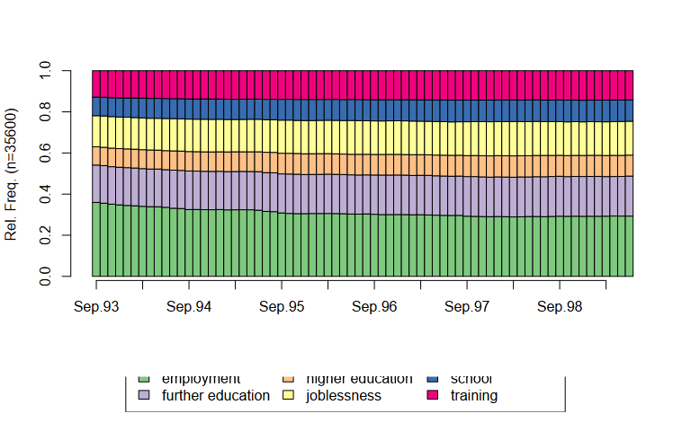

```r
plot(bcq.combined, type="seqdplot")
```

Time for this code chunk to run: 0.53 seconds

The overall distribution of the CQI values can be plotted using `type="density"`. In this case, one also needs to specify the CQI to be used. All tested number of groups are found to be significant. Any CQI computed by `as.clustrange()` can be used here. To show the density of the average silhouette width (`"ASW"`), one can use:

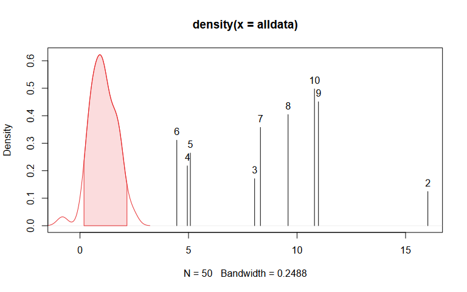

```r
plot(bcq.combined, stat="ASW", type="density")
```

Time for this code chunk to run: 0.09 seconds

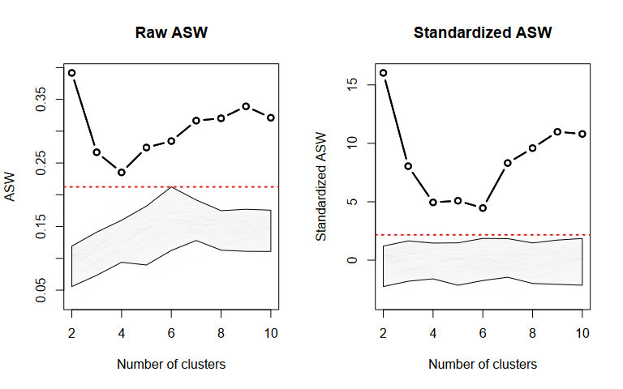

```r
plot(bcq.combined, stat="ASW", type="line")
```

Time for this code chunk to run: 0.16 seconds

## Randomized Sequencing

To use another null model, one needs to change the `model` argument of the `seqnullcqi` function. The randomized sequencing keep the duration attached to each state, but randomizes the ordering of the spells. It can be used to uncover sequencing structure of the data.

```r
bcq.seq <- seqnullcqi(mvad.seq, clustqual, R=50, model="sequencing", seqdist.args=list(method="HAM"), hclust.method="ward.D", parallel = TRUE)
```

Time for this code chunk to run: 70.13 seconds

We can then plot the results as before. Notice that solutions between 3 and 6 are below the critical line.

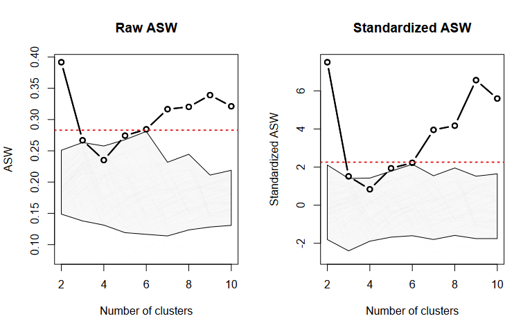

```r
plot(bcq.seq, stat="ASW", type="line")
```

Time for this code chunk to run: 0.19 seconds

## Randomized Duration

The randomized duration keeps the same ordering of the states, but randomizes the time spent in each spell. It can be used to uncover the duration-related structure of the data.

```r
bcq.dur <- seqnullcqi(mvad.seq, clustqual, R=50, model="duration", seqdist.args=list(method="HAM"), hclust.method="ward.D", parallel = TRUE)
```

Time for this code chunk to run: 69.73 seconds

We can then plot the results as before. The solutions 3 and 4 groups solutions are below the “significance line”. Otherwise, the ranking of the solutions is the same.

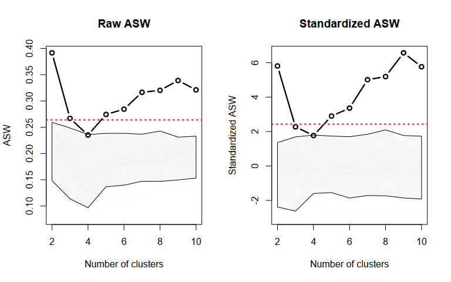

```r
plot(bcq.dur, stat="ASW", type="line")
```

Time for this code chunk to run: 0.18 seconds

## State Independence

The state independence null model generates sequence, position by position, independently of the previous state. This is a quite unrealistic assumption for longitudinal data, but a common one in statistical modeling.

```r
bcq.stateindep <- seqnullcqi(mvad.seq, clustqual, R=50, model="stateindep", seqdist.args=list(method="HAM"), hclust.method="ward.D", parallel = TRUE)
```

Time for this code chunk to run: 69.4 seconds

Bootstrapped CQI values are extremely low compared to our clustering, meaning that we have a strong longitudinal structure (not surprising!).

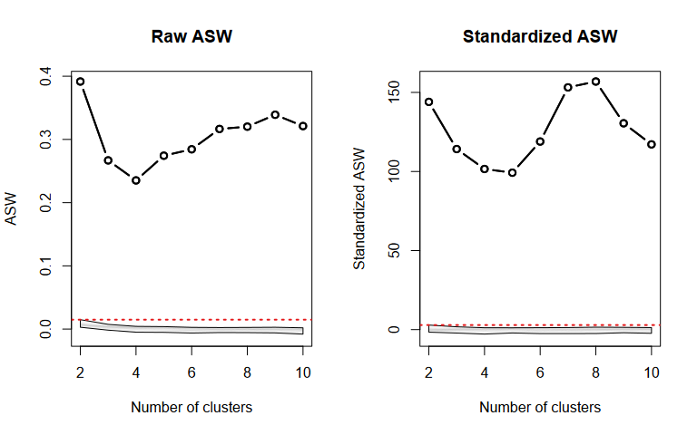

```r
plot(bcq.stateindep, stat="ASW", type="line")
```

Time for this code chunk to run: 0.13 seconds

## First-order Markov Null Model

The first-order Markov null model generates sequences using time-invariant transition rates. As a result, the generated sequences are often quite similar to the observed ones. This model can uncover structure stemming from time-dependent transition rates.

```r
bcq.Markov <- seqnullcqi(mvad.seq, clustqual, R=50, model="Markov", seqdist.args=list(method="HAM"), hclust.method="ward.D", parallel = TRUE)
```

Time for this code chunk to run: 69.18 seconds

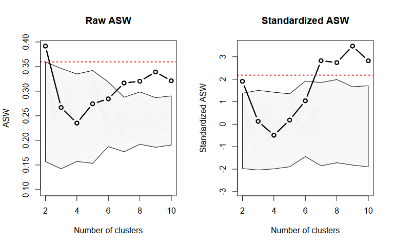

```r
plot(bcq.Markov, stat="ASW", type="line")
```

Time for this code chunk to run: 0.2 seconds

# Choosing a Solution

The various null models lead to the same conclusions and ranking of the solutions. Solutions between 3 and 6 groups were not always above the critical lines (in the sequencing null model for instance), and can be avoided. We generally saw good clustering quality for a clustering in 9 groups. The solution is shown below.

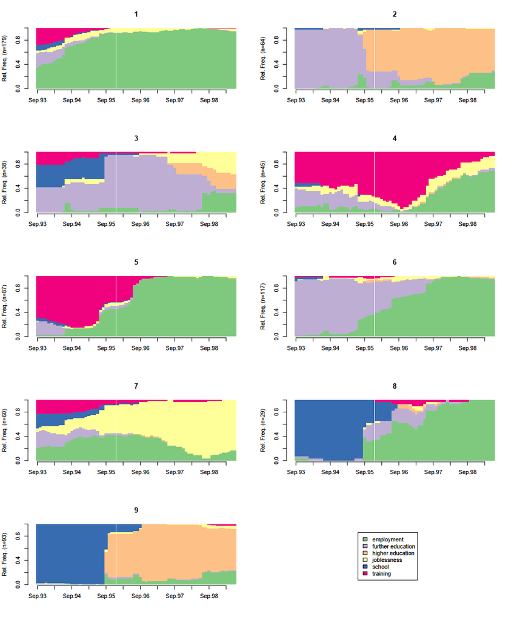

```r
seqdplot(mvad.seq, clustqual$clustering$cluster9, border=NA)
```

Time for this code chunk to run: 0.66 seconds

Studer, Matthias. 2021. “Validating Sequence Analysis Typologies Using Parametric Bootstrap.” *Sociological Methodology* 51 (2): 290–318. https://doi.org/10.1177/00811750211014232.